[Edit on GitHub](https://github.com/DanielVandH/DelaunayTriangulation.jl/tree/main/docs/src/literate_applications/edge_flipping.jl)

# Example Applications

## Edge Flipping

In this application, we implement the edge flipping algorithm for computing an (unconstrained) Delaunay triangulation; constrained triangulations are possible, but we do not consider this here. (This is not the algorithm used in this package, since it is extremely slow.) This algorithm, as described by de Berg et al. in the book *Computational Geometry: Algorithms and Applications* (3 ed., 2008), is as follows: For a given point set $P$ and some initial triangulation $\mathcal T$ of the point set:

```julia
while contains_an_illegal_edge(𝒯)
  eᵢⱼ = an_illegal_edge(𝒯)
  Tᵢⱼₖ, Tⱼᵢᵣ = triangles_adjacent_to_edge(𝒯, eᵢⱼ)
  flip_edge!(𝒯, eᵢⱼ)
  ## flip_edge!(𝒯, eᵢⱼ) means to delete Tᵢⱼₖ and Tⱼᵢᵣ, and add Tᵢₖᵣ and Tⱼᵣₖ
end
```

Here, `eᵢⱼ` denotes the edge $e_{ij} = \overline{p_ip_j}$, where $p_i$ is the $i$th point, and `Tᵢⱼₖ` is the triangle $T_{ijk} = \triangle p_ip_jp_k$. The edge $e_{ij}$ is *illegal* if the circle through $p_i$, $p_j$, and $p_k$ contains $p_r$ in its interior, where $p_k$ and $p_r$ are the other points on the triangles adjoining $e_{ij}$. The idea behind the algorithm is that flipping illegal edges *increases* the minimum angle of the triangulation, and thus, since the Delaunay triangulation is the triangulation with the largest minimum angle, the algorithm converges to the Delaunay triangulation and does so in a finite number of steps. For our implementation of this algorithm, we won't be dealing with issues with degeneracies and collinear points just to simplify the exposition.

One complication with the algorithm is that we need to find a way to construct an initial triangulation $\mathcal T$ for the given set of points. One way to do this is to construct the convex hull, pick one point on the convex hull and connect all other points on the convex hull to that point, and then for all remaining points in the set, find the triangle that contains the point and add the point to the triangulation, connecting that point to the triangle's vertices. Here is one implementation of this.

```julia
using DelaunayTriangulation
using CairoMakie
using StableRNGs

function get_initial_triangulation(points)
    # Get the convex hull
    ch = convex_hull(points)
    idx = get_indices(ch)

    # Get an empty triangulation to start
    tri = Triangulation(points)

    # Now connect each point to the first vertex. Note that the convex hull
    # is given in a counter-clockwise order.
    for i in 2:(length(idx)-2)
        add_triangle!(tri, idx[begin], idx[i], idx[i+1])
    end

    # Now, for all the remaining points, split the triangle that they are inside of
    interior_vertices = setdiff(each_point_index(points), idx)
    for r in interior_vertices
        T = jump_and_march(tri, get_point(tri, r))
        i, j, k = indices(T)
        split_triangle!(tri, i, j, k, r)
    end
    return tri
end
```

```
get_initial_triangulation (generic function with 1 method)
```

As an example:

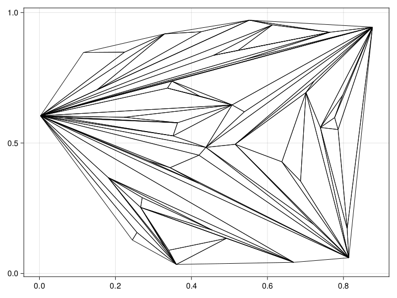

```julia
rng = StableRNG(123)
points = rand(rng, 2, 50)
tri = get_initial_triangulation(points)
fig, ax, sc = triplot(tri)
fig
```

Now we need to write the function that does the flipping. To keep track of what edges are illegal, we initialise by assuming that all edges are illegal, and we repeatedly check the first edge in the set. When an edge is illegal, we flip it. When an edge $e_{ij}$, with adjacent triangles $T_{ijk}$ and $T_{jir}$, is flipped, the new triangles are $T_{ikr}$ and $T_{jr k}$, and the edges that need to be checked are $e_{ik}$ and $e_{kj}$. With this in mind, here is the implementation.

```julia
function edge_flipping_step!(tri, illegal_edges)
    e = first(illegal_edges)
    i, j = edge_indices(e)
    cert = DelaunayTriangulation.is_legal(tri, i, j)
    if DelaunayTriangulation.is_illegal(cert)
        flip_edge!(tri, i, j)
        k = get_adjacent(tri, i, j)
        delete!(illegal_edges, e)
        push!(illegal_edges, (i, k), (k, j))
    else
        delete!(illegal_edges, e)
    end
    return tri
end
function edge_flipping_algorithm!(tri) # tri: an initial triangulation
    illegal_edges = each_edge(tri)
    while !isempty(illegal_edges)
        edge_flipping_step!(tri, illegal_edges)
    end
    return tri
end
function edge_flipping_algorithm(points)
    tri = get_initial_triangulation(points)
    edge_flipping_algorithm!(tri)
    return tri
end
```

```
edge_flipping_algorithm (generic function with 1 method)
```

Here is an example, comparing the triangulation to the triangulation obtained with `triangulate`.

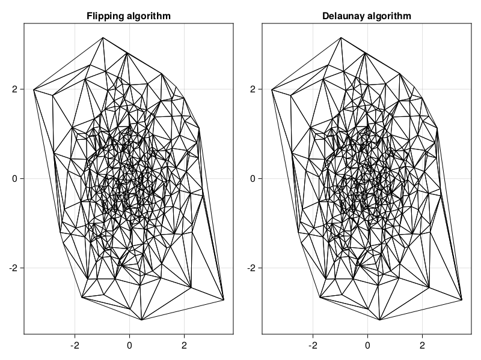

```julia
rng = StableRNG(17423)
points = randn(rng, 2, 500)
tri_flip = edge_flipping_algorithm(points)
tri_delaunay = triangulate(points)
fig, ax, sc = triplot(tri_flip; axis=(title="Flipping algorithm",))
triplot!(Axis(fig[1, 2], title="Delaunay algorithm"), tri_delaunay)
fig
```

```julia
DelaunayTriangulation.compare_triangle_collections(
    get_triangles(tri_flip),
    get_triangles(tri_delaunay)
)
```

```
true
```

Here is an animation of the flipping algorithm in action.

```julia
rng = StableRNG(17423)
points = randn(rng, 2, 100)
tri = get_initial_triangulation(points)
illegal_edges = each_edge(tri)
fig = Figure()
ax = Axis(fig[1, 1])
_tri = Observable(tri)
triplot!(ax, _tri)
record(fig, "flipping_anim.mp4", framerate=24) do io
    ctr = 1
    while !isempty(illegal_edges)
        _tri[] = edge_flipping_step!(_tri[], illegal_edges)
        ctr % 6 == 0 && recordframe!(io) # don't need to show every single edge flip
        ctr += 1
    end
end
```

```
"flipping_anim.mp4"
```

[video not shown]

The next application shows an algorithm that makes this flipping procedure much more efficient.

## Just the code

An uncommented version of this example is given below. You can view the source code for this file [here](https://github.com/DanielVandH/DelaunayTriangulation.jl/tree/new-docs/docs/src/literate_applications/edge_flipping.jl).

```julia
using DelaunayTriangulation
using CairoMakie
using StableRNGs

function get_initial_triangulation(points)
    # Get the convex hull
    ch = convex_hull(points)
    idx = get_indices(ch)

    # Get an empty triangulation to start
    tri = Triangulation(points)

    # Now connect each point to the first vertex. Note that the convex hull
    # is given in a counter-clockwise order.
    for i in 2:(length(idx)-2)
        add_triangle!(tri, idx[begin], idx[i], idx[i+1])
    end

    # Now, for all the remaining points, split the triangle that they are inside of
    interior_vertices = setdiff(each_point_index(points), idx)
    for r in interior_vertices
        T = jump_and_march(tri, get_point(tri, r))
        i, j, k = indices(T)
        split_triangle!(tri, i, j, k, r)
    end
    return tri
end

rng = StableRNG(123)
points = rand(rng, 2, 50)
tri = get_initial_triangulation(points)
fig, ax, sc = triplot(tri)
fig

function edge_flipping_step!(tri, illegal_edges)
    e = first(illegal_edges)
    i, j = edge_indices(e)
    cert = DelaunayTriangulation.is_legal(tri, i, j)
    if DelaunayTriangulation.is_illegal(cert)
        flip_edge!(tri, i, j)
        k = get_adjacent(tri, i, j)
        delete!(illegal_edges, e)
        push!(illegal_edges, (i, k), (k, j))
    else
        delete!(illegal_edges, e)
    end
    return tri
end
function edge_flipping_algorithm!(tri) # tri: an initial triangulation
    illegal_edges = each_edge(tri)
    while !isempty(illegal_edges)
        edge_flipping_step!(tri, illegal_edges)
    end
    return tri
end
function edge_flipping_algorithm(points)
    tri = get_initial_triangulation(points)
    edge_flipping_algorithm!(tri)
    return tri
end

rng = StableRNG(17423)
points = randn(rng, 2, 500)
tri_flip = edge_flipping_algorithm(points)
tri_delaunay = triangulate(points)
fig, ax, sc = triplot(tri_flip; axis=(title="Flipping algorithm",))
triplot!(Axis(fig[1, 2], title="Delaunay algorithm"), tri_delaunay)
fig

DelaunayTriangulation.compare_triangle_collections(
    get_triangles(tri_flip),
    get_triangles(tri_delaunay)
)

rng = StableRNG(17423)
points = randn(rng, 2, 100)
tri = get_initial_triangulation(points)
illegal_edges = each_edge(tri)
fig = Figure()
ax = Axis(fig[1, 1])
_tri = Observable(tri)
triplot!(ax, _tri)
record(fig, "flipping_anim.mp4", framerate=24) do io
    ctr = 1
    while !isempty(illegal_edges)
        _tri[] = edge_flipping_step!(_tri[], illegal_edges)
        ctr % 6 == 0 && recordframe!(io) # don't need to show every single edge flip
        ctr += 1
    end
end
```

*This page was generated using Literate.jl.*